# Linear Models, Problem 4

alexaoh

26 oktober, 2021

```r
data <- read.csv2("dcrown.csv")
data$RP <- data$PB/data$PT # Add the given ratio to the data.
head(data)
```

```
#>   DCrown   PB   PT   HT  A       RP
#> 1   5.19 0.92 0.62 2.70 16 1.483871
#> 2   7.03 1.00 0.72 2.54  7 1.388889
#> 3   3.51 0.52 0.36 2.09  7 1.444444
#> 4   5.25 0.72 0.54 2.88 16 1.333333
#> 5   5.33 0.93 0.67 2.90 16 1.388060
#> 6   5.46 0.90 0.65 2.72 16 1.384615
```

```r
dim(data)
```

```
#> [1] 311   6
```

```r
summary(data)
```

```
#>      DCrown             PB              PT               HT
#>  Min.   : 1.870   Min.   :0.280   Min.   :0.1800   Min.   :1.690
#>  1st Qu.: 3.905   1st Qu.:0.600   1st Qu.:0.4050   1st Qu.:2.325
#>  Median : 4.920   Median :0.760   Median :0.5400   Median :2.590
#>  Mean   : 4.991   Mean   :0.761   Mean   :0.5345   Mean   :2.546
#>  3rd Qu.: 5.930   3rd Qu.:0.905   3rd Qu.:0.6400   3rd Qu.:2.770
#>  Max.   :11.030   Max.   :1.440   Max.   :1.0000   Max.   :3.470
#>        A              RP
#>  Min.   : 7.0   Min.   :1.103
#>  1st Qu.: 7.0   1st Qu.:1.367
#>  Median :16.0   Median :1.418
#>  Mean   :12.1   Mean   :1.433
#>  3rd Qu.:16.0   3rd Qu.:1.487
#>  Max.   :22.0   Max.   :1.750
```

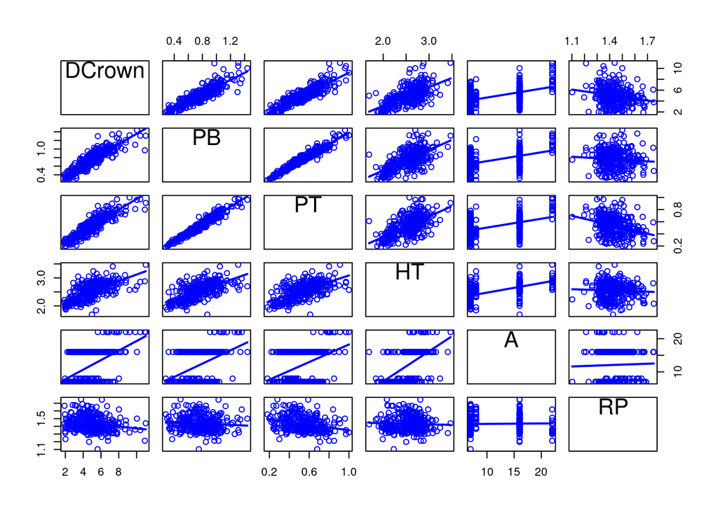

```r
scatterplotMatrix(data, smooth = F, diagonal = F)
```

### Consider Two Different Linear Models

```r
modA <- lm(DCrown~PT+RP+HT+A, data = data)
summary(modA)
```

```
#>
#> Call:
#> lm(formula = DCrown ~ PT + RP + HT + A, data = data)
#>
#> Residuals:
#>     Min      1Q  Median      3Q     Max
#> -2.4770 -0.4398 -0.0358  0.3922  3.4693
#>
#> Coefficients:
#>             Estimate Std. Error t value Pr(>|t|)
#> (Intercept) -1.84147    0.73373  -2.510  0.01260 *
#> PT           8.45921    0.34915  24.228  < 2e-16 ***
#> RP           0.77674    0.44621   1.741  0.08273 .
#> HT           0.33440    0.19159   1.745  0.08192 .
#> A            0.02863    0.01026   2.792  0.00558 **
#> ---
#> Signif. codes:  0 '***' 0.001 '**' 0.01 '*' 0.05 '.' 0.1 ' ' 1
#>
#> Residual standard error: 0.7213 on 306 degrees of freedom
#> Multiple R-squared:  0.8124, Adjusted R-squared:   0.81
#> F-statistic: 331.4 on 4 and 306 DF,  p-value: < 2.2e-16
```

```r
modB <- lm(log(DCrown)~log(PT)+log(RP)+log(HT)+log(A), data = data)
summary(modB)
```

```
#>
#> Call:
#> lm(formula = log(DCrown) ~ log(PT) + log(RP) + log(HT) + log(A),
#>     data = data)
#>
#> Residuals:
#>      Min       1Q   Median       3Q      Max
#> -0.35655 -0.09336 -0.00394  0.09086  0.45920
#>
#> Coefficients:
#>             Estimate Std. Error t value Pr(>|t|)
#> (Intercept)  1.69533    0.09994  16.964   <2e-16 ***
#> log(PT)      0.88111    0.03435  25.653   <2e-16 ***
#> log(RP)      0.28075    0.12723   2.207   0.0281 *
#> log(HT)      0.23307    0.09806   2.377   0.0181 *
#> log(A)       0.05636    0.02291   2.461   0.0144 *
#> ---
#> Signif. codes:  0 '***' 0.001 '**' 0.01 '*' 0.05 '.' 0.1 ' ' 1
#>
#> Residual standard error: 0.1422 on 306 degrees of freedom
#> Multiple R-squared:  0.8345, Adjusted R-squared:  0.8323
#> F-statistic: 385.7 on 4 and 306 DF,  p-value: < 2.2e-16
```

### a) Questions about `modA`

1. All the coefficient estimates are not significantly different from zero, with a significance level of 5%. Only `PT` and `A` (plus the intercept) are significant to this level.
2. The estimation of the residual variance is $(\text{Residual standard error})^2$ = 0.5202814.

Residual plot is given below. Looks like it is hard to assume homoscedasticity in this case.

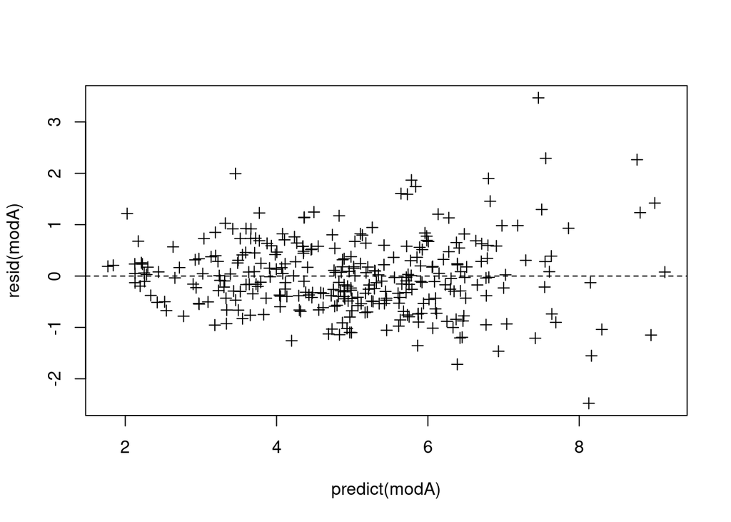

```r
plot(predict(modA), resid(modA), pch = 3)
abline(h=0, lty = 2)
```

Model diagnostics are done below.

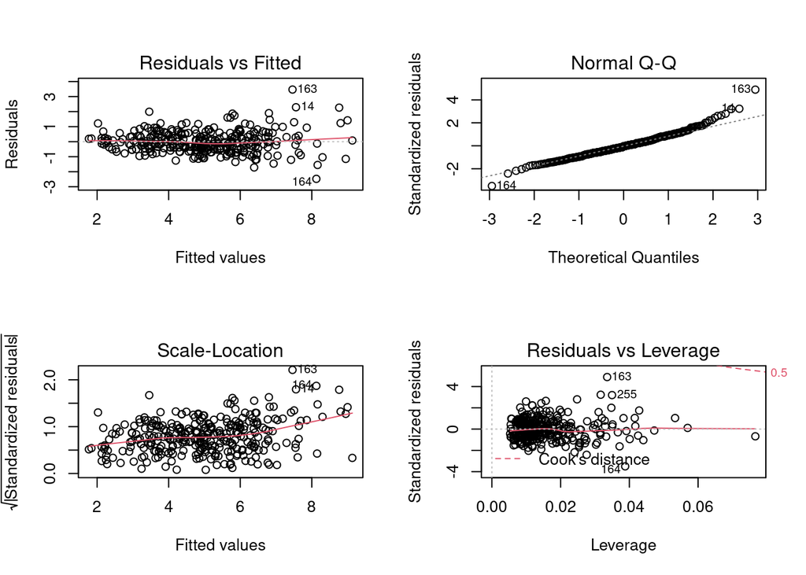

```r
par(mfrow = c(2,2))
plot(modA)
```

```r
par(mfrow = c(1,1))
```

3. The studentized residuals are plotted below.

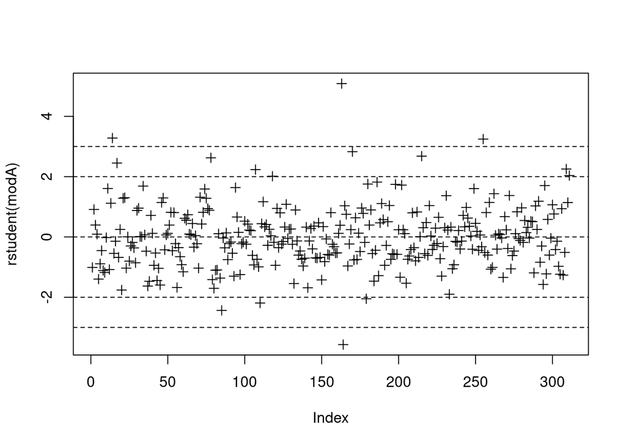

```r
plot(rstudent(modA), pch = 3)
abline(h = c(-3, -2, 0, 2, 3), lty = 2)
```

As is apparent, 15 points are outside the interval (-2,2). This represents a percentage of approximately 4.82 % of the points, which is reasonable, considering $1.96 \approx 2$, where 1.96 is the 0.975 quantile of the standard normal distribution. Hence, (-2,2) is an approximation of a 5% confidence interval.

### b) Questions about `modB`

1. In the second model all the coefficient estimates are significantly different from zero, with a significance level of 5%.
2. The estimation of the residual variance is $(\text{Residual standard error})^2$ = 0.0202191.

Residual plot is given below. Looks better.

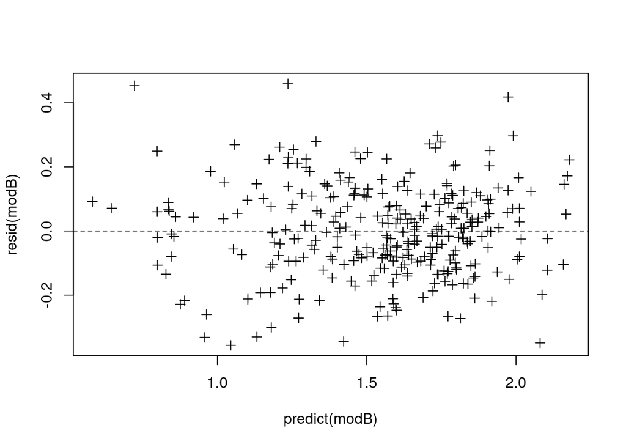

```r
plot(predict(modB), resid(modB), pch = 3)
abline(h=0, lty = 2)
```

Model diagnostics are done below.

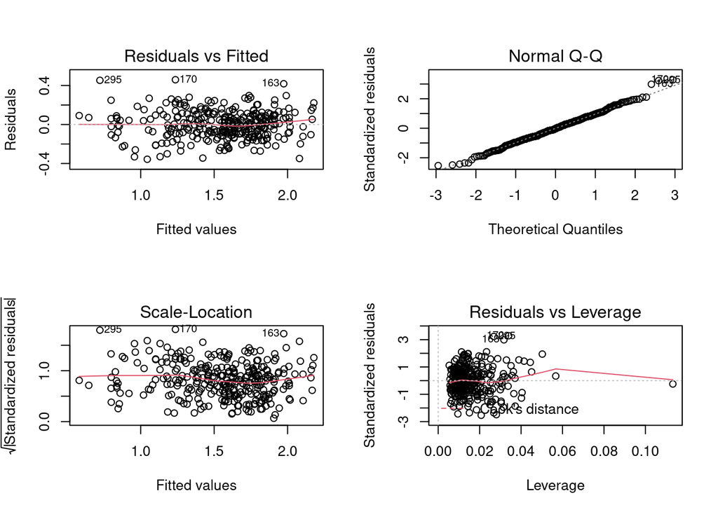

```r
par(mfrow = c(2,2))
plot(modB)
```

```r
par(mfrow = c(1,1))
```

3. The studentized residuals are plotted below.

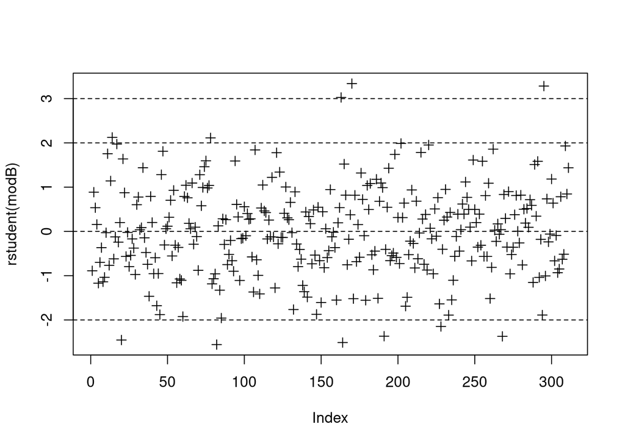

```r
plot(rstudent(modB), pch = 3)
abline(h = c(-3, -2, 0, 2, 3), lty = 2)
```

As is apparent, 11 points are outside the interval (-2,2). This represents a percentage of approximately 3.54% of the points, which is reasonable, considering $1.96 \approx 2$, where 1.96 is the 0.975 quantile of the standard normal distribution. Hence, (-2,2) is an approximation of a 5% confidence interval.

### c)

I would choose `modB` since, compared to `modB`, $R^2$ is larger, the F-statistic is larger (even though both have small $p$-values for the F-test) and all the coefficients are significant (in contrast to the first model, which only has a few estimates that are significantly non-zero, to a 5% level). Note that I have assumed that the assumptions of the linear model are verified for both models (as it says in the problem), which is why these assumptions are not discussed.

### d)

```r
# Do not need to do the following (see row below) since the variables are log-transformed in the model.
#new.data <- data.frame(PT = log(0.4), PB = log(0.6), HT = log(2.3), A = log(10), RP = log(0.6/0.4))
new.data <- data.frame(PT = 0.4, PB = 0.6, HT = 2.3, A = 10, RP = 0.6/0.4)
exp(predict(modB, new.data, interval = "prediction", level = 0.95)) # Transform back to correct dimension.
```

```
#>        fit      lwr      upr
#> 1 3.764868 2.843311 4.985115
```